# Tiny Project: Student Performance and Lifestyle Factors Analysis

Serafim Ferando Augusto-2505101270238

2026-09-22

## 1. Introduction

Student academic performance depends on more than just study effort — family background, lifestyle habits, and school support all play a role. This Tiny Project uses a real student survey dataset (395 students, 31 variables) to explore which factors are associated with whether a student **passed** or **failed**. The workflow follows the steps covered in Practicals 8, 9 and 10: data importing, preprocessing, statistical exploration, visualization, and interpretation.

## 2. Data Importing

```r
# Read the CSV file into a data frame.
# stringsAsFactors = FALSE keeps text columns as character for now;
# we convert the relevant ones to factors ourselves in the next section.
student_data <- read.csv("student-data.csv", stringsAsFactors = FALSE)

# Quick look at the data
dim(student_data)      # rows and columns
```

```
## [1] 395  31
```

```r
head(student_data)      # first six records
```

```
##   school sex age address famsize Pstatus Medu Fedu     Mjob     Fjob     reason
## 1     GP   F  18       U     GT3       A    4    4  at_home  teacher     course
## 2     GP   F  17       U     GT3       T    1    1  at_home    other     course
## 3     GP   F  15       U     LE3       T    1    1  at_home    other      other
## 4     GP   F  15       U     GT3       T    4    2   health services       home
## 5     GP   F  16       U     GT3       T    3    3    other    other       home
## 6     GP   M  16       U     LE3       T    4    3 services    other reputation
##   guardian traveltime studytime failures schoolsup famsup paid activities
## 1   mother          2         2        0       yes     no   no         no
## 2   father          1         2        0        no    yes   no         no
## 3   mother          1         2        3       yes     no  yes         no
## 4   mother          1         3        0        no    yes  yes        yes
## 5   father          1         2        0        no    yes  yes         no
## 6   mother          1         2        0        no    yes  yes        yes
##   nursery higher internet romantic famrel freetime goout Dalc Walc health
## 1     yes    yes       no       no      4        3     4    1    1      3
## 2      no    yes      yes       no      5        3     3    1    1      3
## 3     yes    yes      yes       no      4        3     2    2    3      3
## 4     yes    yes      yes      yes      3        2     2    1    1      5
## 5     yes    yes       no       no      4        3     2    1    2      5
## 6     yes    yes      yes       no      5        4     2    1    2      5
##   absences passed
## 1        6     no
## 2        4     no
## 3       10    yes
## 4        2    yes
## 5        4    yes
## 6       10    yes
```

```r
str(student_data)       # structure and data types of each column
```

```
## 'data.frame':    395 obs. of  31 variables:
##  $ school    : chr  "GP" "GP" "GP" "GP" ...
##  $ sex       : chr  "F" "F" "F" "F" ...
##  $ age       : int  18 17 15 15 16 16 16 17 15 15 ...
##  $ address   : chr  "U" "U" "U" "U" ...
##  $ famsize   : chr  "GT3" "GT3" "LE3" "GT3" ...
##  $ Pstatus   : chr  "A" "T" "T" "T" ...
##  $ Medu      : int  4 1 1 4 3 4 2 4 3 3 ...
##  $ Fedu      : int  4 1 1 2 3 3 2 4 2 4 ...
##  $ Mjob      : chr  "at_home" "at_home" "at_home" "health" ...
##  $ Fjob      : chr  "teacher" "other" "other" "services" ...
##  $ reason    : chr  "course" "course" "other" "home" ...
##  $ guardian  : chr  "mother" "father" "mother" "mother" ...
##  $ traveltime: int  2 1 1 1 1 1 1 2 1 1 ...
##  $ studytime : int  2 2 2 3 2 2 2 2 2 2 ...
```

[output cut: 17 more lines]

**Explanation:** `read.csv()` loads the dataset from the working directory. `dim()`, `head()` and `str()` give a first impression of the data’s size, sample rows, and column types before any cleaning is done.

## 3. Data Preprocessing and Cleaning

```r
# Check for missing values in every column
colSums(is.na(student_data))
```

```
##     school        sex        age    address    famsize    Pstatus       Medu
##          0          0          0          0          0          0          0
##       Fedu       Mjob       Fjob     reason   guardian traveltime  studytime
##          0          0          0          0          0          0          0
##   failures  schoolsup     famsup       paid activities    nursery     higher
##          0          0          0          0          0          0          0
##   internet   romantic     famrel   freetime      goout       Dalc       Walc
##          0          0          0          0          0          0          0
##     health   absences     passed
##          0          0          0
```

```r
# Check for duplicate rows
sum(duplicated(student_data))
```

```
## [1] 0
```

```r
# Convert key categorical columns to factors for correct summarisation/plots
cat_cols <- c("school", "sex", "address", "famsize", "Pstatus", "Mjob",
              "Fjob", "reason", "guardian", "schoolsup", "famsup", "paid",
              "activities", "nursery", "higher", "internet", "romantic",
              "passed")
student_data[cat_cols] <- lapply(student_data[cat_cols], factor)

# Create one derived feature: average weekly alcohol consumption
# (mean of workday alcohol use 'Dalc' and weekend alcohol use 'Walc')
student_data$alc_avg <- (student_data$Dalc + student_data$Walc) / 2

str(student_data[c(cat_cols, "alc_avg")])
```

```
## 'data.frame':    395 obs. of  19 variables:
##  $ school    : Factor w/ 2 levels "GP","MS": 1 1 1 1 1 1 1 1 1 1 ...
##  $ sex       : Factor w/ 2 levels "F","M": 1 1 1 1 1 2 2 1 2 2 ...
##  $ address   : Factor w/ 2 levels "R","U": 2 2 2 2 2 2 2 2 2 2 ...
##  $ famsize   : Factor w/ 2 levels "GT3","LE3": 1 1 2 1 1 2 2 1 2 1 ...
##  $ Pstatus   : Factor w/ 2 levels "A","T": 1 2 2 2 2 2 2 1 1 2 ...
##  $ Mjob      : Factor w/ 5 levels "at_home","health",..: 1 1 1 2 3 4 3 3 4 3 ...
##  $ Fjob      : Factor w/ 5 levels "at_home","health",..: 5 3 3 4 3 3 3 5 3 3 ...
##  $ reason    : Factor w/ 4 levels "course","home",..: 1 1 3 2 2 4 2 2 2 2 ...
##  $ guardian  : Factor w/ 3 levels "father","mother",..: 2 1 2 2 1 2 2 2 2 2 ...
##  $ schoolsup : Factor w/ 2 levels "no","yes": 2 1 2 1 1 1 1 2 1 1 ...
##  $ famsup    : Factor w/ 2 levels "no","yes": 1 2 1 2 2 2 1 2 2 2 ...
##  $ paid      : Factor w/ 2 levels "no","yes": 1 1 2 2 2 2 1 1 2 2 ...
##  $ activities: Factor w/ 2 levels "no","yes": 1 1 1 2 1 2 1 1 1 2 ...
##  $ nursery   : Factor w/ 2 levels "no","yes": 2 1 2 2 2 2 2 2 2 2 ...
##  $ higher    : Factor w/ 2 levels "no","yes": 2 2 2 2 2 2 2 2 2 2 ...
##  $ internet  : Factor w/ 2 levels "no","yes": 1 2 2 2 1 2 2 1 2 2 ...
##  $ romantic  : Factor w/ 2 levels "no","yes": 1 1 1 2 1 1 1 1 1 1 ...
##  $ passed    : Factor w/ 2 levels "no","yes": 1 1 2 2 2 2 2 1 2 2 ...
##  $ alc_avg   : num  1 1 2.5 1 1.5 1.5 1 1 1 1 ...
```

**Explanation:** `colSums(is.na(...))` confirms the dataset has no missing values, and `duplicated()` confirms there are no duplicate rows, so no imputation or row-dropping is required. The categorical text columns are converted to `factor` type so R treats them correctly in summaries and plots. `alc_avg` is a new engineered feature combining weekday and weekend alcohol consumption into a single lifestyle indicator used later in the analysis.

## 4. Data Analysis and Statistical Exploration

```r
# Overall summary statistics for numeric columns
summary(student_data[, c("age", "studytime", "failures", "absences",
                          "alc_avg")])
```

```
##       age         studytime        failures         absences
##  Min.   :15.0   Min.   :1.000   Min.   :0.0000   Min.   : 0.000
##  1st Qu.:16.0   1st Qu.:1.000   1st Qu.:0.0000   1st Qu.: 0.000
##  Median :17.0   Median :2.000   Median :0.0000   Median : 4.000
##  Mean   :16.7   Mean   :2.035   Mean   :0.3342   Mean   : 5.709
##  3rd Qu.:18.0   3rd Qu.:2.000   3rd Qu.:0.0000   3rd Qu.: 8.000
##  Max.   :22.0   Max.   :4.000   Max.   :3.0000   Max.   :75.000
##     alc_avg
##  Min.   :1.000
##  1st Qu.:1.000
##  Median :1.500
##  Mean   :1.886
##  3rd Qu.:2.500
##  Max.   :5.000
```

```r
# How many students passed vs failed?
table(student_data$passed)
```

```
##
##  no yes
## 130 265
```

```r
# Pass rate by gender
prop.table(table(student_data$sex, student_data$passed), margin = 1)
```

```
##
##            no       yes
##   F 0.3605769 0.6394231
##   M 0.2941176 0.7058824
```

```r
# Pass rate by weekly study time category (1=<2hrs, 2=2-5hrs, 3=5-10hrs, 4=>10hrs)
tapply(student_data$passed == "yes", student_data$studytime, mean)
```

```
##         1         2         3         4
## 0.6476190 0.6464646 0.7538462 0.7407407
```

```r
# Average absences for students who passed vs failed
tapply(student_data$absences, student_data$passed, mean)
```

```
##       no      yes
## 6.761538 5.192453
```

```r
# Correlation between numeric lifestyle/background variables and absences
num_cols <- c("age", "Medu", "Fedu", "traveltime", "studytime", "failures",
              "famrel", "freetime", "goout", "Dalc", "Walc", "health",
              "absences")
cor(student_data[num_cols])[, "absences"]
```

```
##         age        Medu        Fedu  traveltime   studytime    failures
##  0.17523008  0.10028482  0.02447289 -0.01294378 -0.06270018  0.06372583
##      famrel    freetime       goout        Dalc        Walc      health
## -0.04435409 -0.05807792  0.04430222  0.11190803  0.13629110 -0.02993671
##    absences
##  1.00000000
```

**Explanation:** `summary()` gives central tendency and spread for the numeric variables. `table()` and `prop.table()` turn the categorical `passed` outcome into counts and proportions, split by gender. `tapply()` computes a statistic (mean) for one variable grouped by another — here, the pass rate by study-time category, and average absences by pass/fail status. `cor()` measures the linear relationship between each numeric variable and absences.

## 5. Graphs and Plots

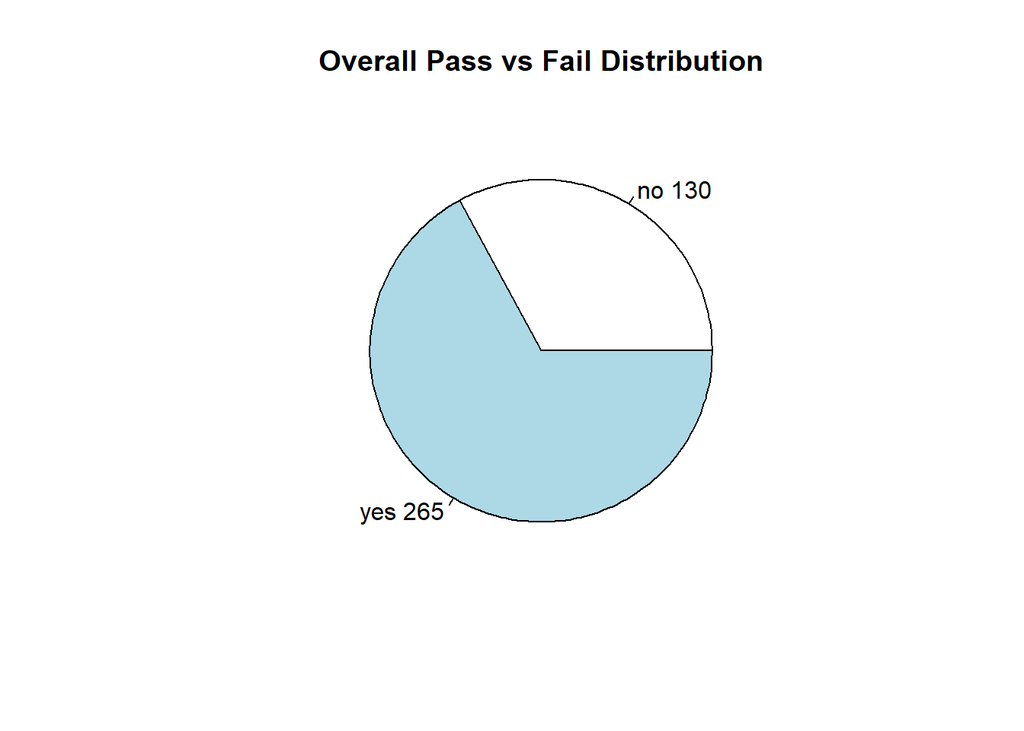

```r
result_count <- table(student_data$passed)
pie(result_count,
    main = "Overall Pass vs Fail Distribution",
    labels = paste(names(result_count), result_count))
```

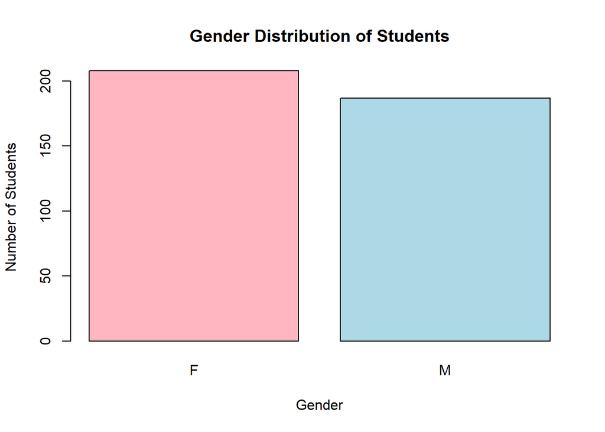

```r
gender_count <- table(student_data$sex)
barplot(gender_count,
        main = "Gender Distribution of Students",
        xlab = "Gender", ylab = "Number of Students",
        col = c("lightpink", "lightblue"))
```

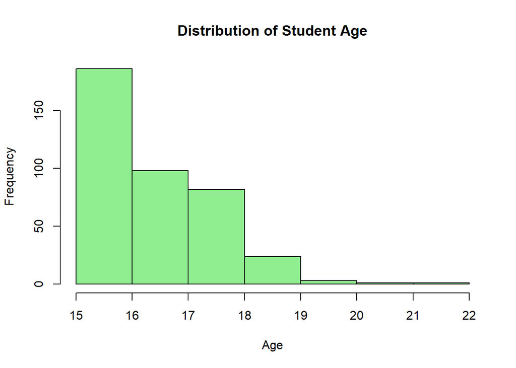

```r
hist(student_data$age,
     main = "Distribution of Student Age",
     xlab = "Age", col = "lightgreen", breaks = 8)
```

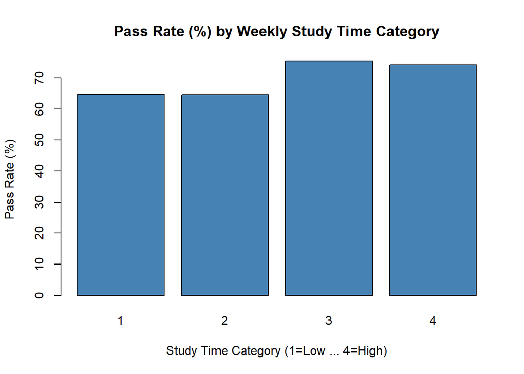

```r
pass_rate_by_study <- tapply(student_data$passed == "yes",
                              student_data$studytime, mean) * 100
barplot(pass_rate_by_study,
        main = "Pass Rate (%) by Weekly Study Time Category",
        xlab = "Study Time Category (1=Low ... 4=High)",
        ylab = "Pass Rate (%)", col = "steelblue")
```